# wrangle_report

### WRANGLING_REPORT

#### Data Wrangling Poject Report,

#### Presented By: Monica Iddah

#### August 11th, 2022

I imported the libraries that are required for the analysis.

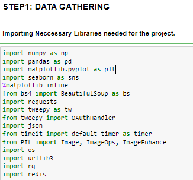

After importing the libraries, tweeter developer account was needed to enable webscraping but a local file was provided by Udacity for those who do not have access to the twitter developer account. The downloaded files were used for this project as I was unable to get access to the twitter developer account.

In this data gathering stage, the collected data from Udacity were read into the pandas data frames one after the other.

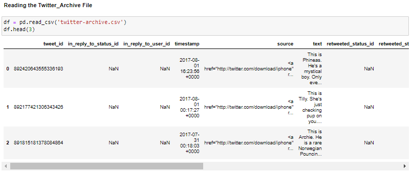

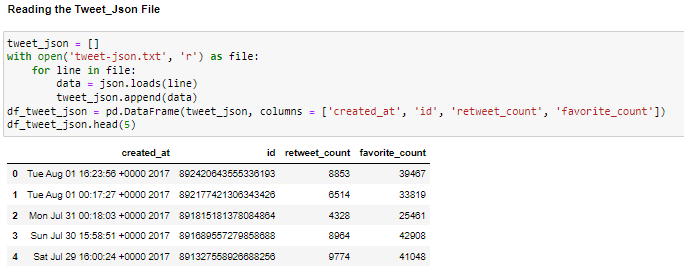

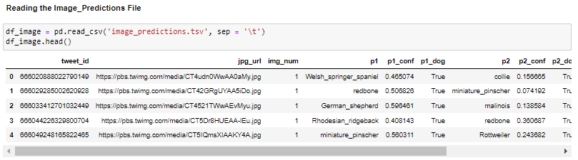

After reading the different dataset provided into the pandas data frames, we move to the next phase, which is data assessment.

The data assessment stage is neccessary as in this stage we take a thorough look into our data set for proer analysis, where we can deduce some tidyness and quality issues found with our data.

Now to the data assessment stage

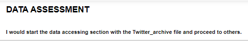

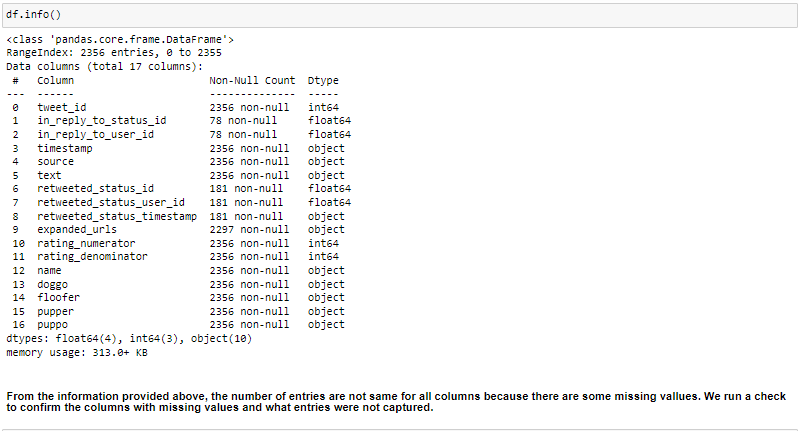

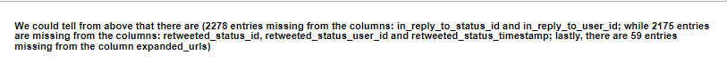

We also analysed the Twitter_Json and the Image_prediction files and deduced the following as our tidyness and quality issues associated with our datasets.

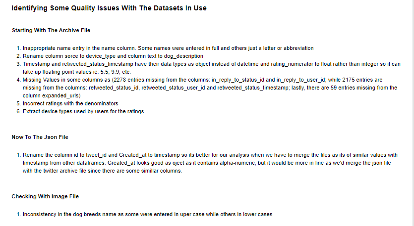

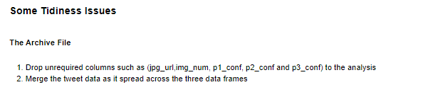

The wrangling process continues after identifying the quality and tidiness issues with the data set. we creat a copy of the original dataset and work with it

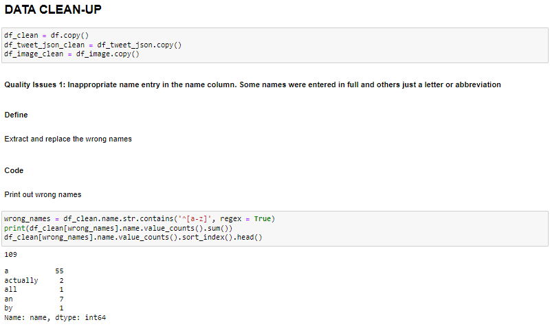

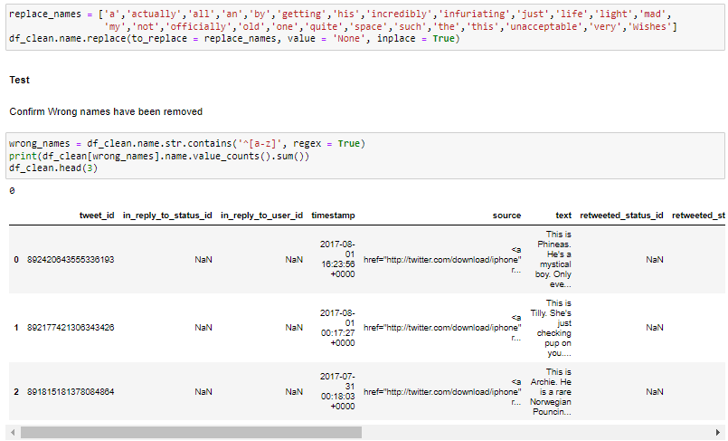

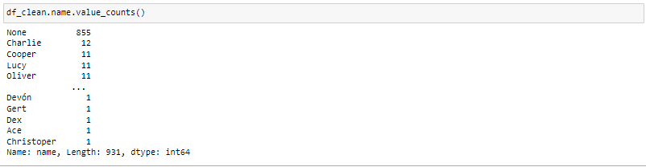

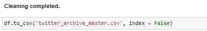

Tha visualization is drawn based on some highlighted theorry from the entire analysis process.

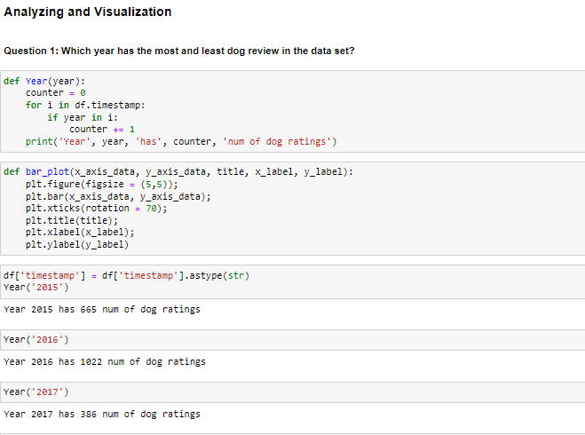

[figure not shown]

The visualization phase brings us to the end of our analysis